# R: Differential Response Functioning statistics

| DRF {mirt} | R Documentation |
| --- | --- |

## Differential Response Functioning statistics

### Description

Function performs various omnibus differential item (DIF), bundle (DBF), and test (DTF) functioning procedures on an object estimated with `multipleGroup()`. The compensatory and non-compensatory statistics provided are described in Chalmers (2018), which generally can be interpreted as IRT generalizations of the SIBTEST and CSIBTEST statistics. For hypothesis tests, these measures require the ACOV matrix to be computed in the fitted multiple-group model (otherwise, sets of plausible draws from the posterior are explicitly required).

### Usage

```r
DRF(
  mod,
  draws = NULL,
  focal_items = 1L:extract.mirt(mod, "nitems"),
  param_set = NULL,
  den.type = "marginal",
  best_fitting = FALSE,
  CI = 0.95,
  npts = 1000,
  quadpts = NULL,
  theta_lim = c(-6, 6),
  Theta_nodes = NULL,
  plot = FALSE,
  DIF = FALSE,
  DIF.cats = FALSE,
  groups2test = "all",
  pairwise = FALSE,
  simplify = TRUE,
  p.adjust = "none",
  par.strip.text = list(cex = 0.7),
  par.settings = list(strip.background = list(col = "#9ECAE1"), strip.border = list(col =
    "black")),
  auto.key = list(space = "right", points = FALSE, lines = TRUE),
  verbose = TRUE,
  ...
)
```

### Arguments

| `mod` | a multipleGroup object which estimated only 2 groups |
| --- | --- |
| `draws` | a number indicating how many draws to take to form a suitable multiple imputation or bootstrap estimate of the expected test scores (100 or more). If `boot = FALSE`, requires an estimated parameter in… |
| `focal_items` | a character/numeric vector indicating which items to include in the DRF tests. The default uses all of the items (note that including anchors in the focal items has no effect because they are exactly … |
| `param_set` | an N x p matrix of parameter values drawn from the posterior (e.g., using the parametric sampling approach, bootstrap, of MCMC). If supplied, then these will be used to compute the DRF measures. Can b… |
| `den.type` | character specifying how the density of the latent traits is computed. Default is `'marginal'` to include the proportional information from both groups, `'focal'` for just the focal group, and `'refer… |
| `best_fitting` | logical; use the best fitting parametric distribution (Gaussian by default) that was used at the time of model estimation? This will result in much fast computations, however the results are more depe… |
| `CI` | range of confidence interval when using draws input |
| `npts` | number of points to use for plotting. Default is 1000 |
| `quadpts` | number of quadrature nodes to use when constructing DRF statistics. Default is extracted from the input model object |
| `theta_lim` | lower and upper limits of the latent trait (theta) to be evaluated, and is used in conjunction with `quadpts` and `npts` |
| `Theta_nodes` | an optional matrix of Theta values to be evaluated in the draws for the sDRF statistics. However, these values are not averaged across, and instead give the bootstrap confidence intervals at the respe… |
| `plot` | logical; plot the 'sDRF' functions for the evaluated sDBF or sDTF values across the integration grid or, if `DIF = TRUE`, the selected items as a faceted plot of individual items? If plausible paramet… |
| `DIF` | logical; return a list of item-level imputation properties using the DRF statistics? These can generally be used as a DIF detection method and as a graphical display for understanding DIF within each … |
| `DIF.cats` | logical; same as `DIF = TRUE`, however computations will be performed on each item category probability functions rather than the score functions. Only useful for understanding DIF in polytomous items |
| `groups2test` | when more than 2 groups are being investigated which two groups should be used in the effect size comparisons? |
| `pairwise` | logical; perform pairwise computations when the applying to multi-group settings |
| `simplify` | logical; attempt to simplify the output rather than returning larger lists? |
| `p.adjust` | string to be passed to the `p.adjust` function to adjust p-values. Adjustments are located in the `adj_pvals` element in the returned list. Only applicable when `DIF = TRUE` |
| `par.strip.text` | plotting argument passed to `lattice` |
| `par.settings` | plotting argument passed to `lattice` |
| `auto.key` | plotting argument passed to `lattice` |
| `verbose` | logical; include additional information in the console? |
| `...` | additional arguments to be passed to `lattice` |

### Details

The effect sizes estimates by the DRF function are

`sDRF = \int [S(C|\bm{\Psi}^{(R)},\theta) S(C|\bm{\Psi}^{(F)},\theta)] f(\theta)d\theta,`

`uDRF = \int |S(C|\bm{\Psi}^{(R)},\theta) S(C|\bm{\Psi}^{(F)},\theta)| f(\theta)d\theta,`

and

`dDRF = \sqrt{\int [S(C|\bm{\Psi}^{(R)},\theta) S(C|\bm{\Psi}^{(F)},\theta)]^2 f(\theta)d\theta}`

where `S(.)` are the scoring equations used to evaluate the model-implied difference between the focal and reference group. The `f(\theta)` terms can either be estimated from the posterior via an empirical histogram approach (default), or can use the best fitting prior distribution that is obtain post-convergence (default is a Guassian distribution). Note that, in comparison to Chalmers (2018), the focal group is the leftmost scoring function while the reference group is the rightmost scoring function. This is largely to keep consistent with similar effect size statistics, such as SIBTEST, DFIT, Wainer's measures of impact, etc, which in general can be seen as special-case estimators of this family.

### Author(s)

Phil Chalmers rphilip.chalmers@gmail.com

### References

Chalmers, R. P. (2018). Model-Based Measures for Detecting and Quantifying Response Bias. *Psychometrika, 83*(3), 696-732. [doi:10.1007/s11336-018-9626-9](https://doi.org/10.1007/s11336-018-9626-9)

### See Also

`multipleGroup`, `DIF`

### Examples

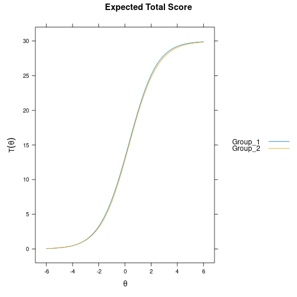

```r
## No test:

set.seed(1234)
n <- 30
N <- 500

# only first 5 items as anchors
model <- 'F = 1-30
          CONSTRAINB = (1-5, a1), (1-5, d)'

a <- matrix(1, n)
d <- matrix(rnorm(n), n)
group <- c(rep('Group_1', N), rep('Group_2', N))

## -------------
# groups completely equal
dat1 <- simdata(a, d, N, itemtype = 'dich')
dat2 <- simdata(a, d, N, itemtype = 'dich')
dat <- rbind(dat1, dat2)
mod <- multipleGroup(dat, model, group=group, SE=TRUE,
                     invariance=c('free_means', 'free_var'))
plot(mod)
```

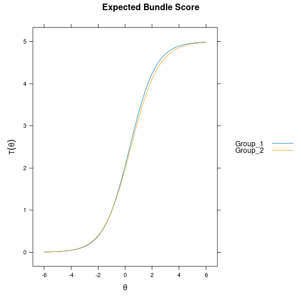

```r
plot(mod, which.items = 6:10) #DBF
```

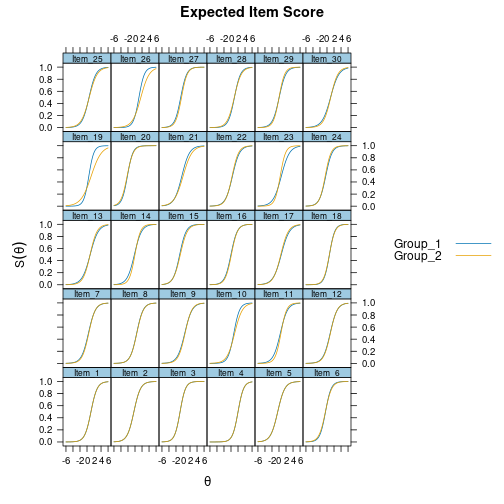

```r
plot(mod, type = 'itemscore')
```

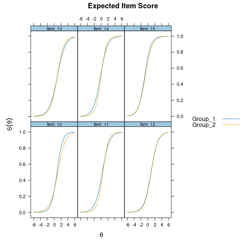

```r
plot(mod, type = 'itemscore', which.items = 10:15)
```

```r
# empirical histogram approach
DRF(mod)
```

```
##            groups n_focal_items   sDRF  uDRF  dDRF
## 1 Group_1,Group_2            30 -0.326 0.326 0.328
```

```r
DRF(mod, focal_items = 6:10) #DBF
```

```
##            groups n_focal_items   sDRF  uDRF  dDRF
## 1 Group_1,Group_2             5 -0.069 0.071 0.084
```

```r
DRF(mod, DIF=TRUE)
```

```
##             groups    item   sDIF  uDIF  dDIF
## 1  Group_1,Group_2  Item_1  0.000 0.000 0.000
## 2  Group_1,Group_2  Item_2  0.000 0.000 0.000
## 3  Group_1,Group_2  Item_3  0.000 0.000 0.000
## 4  Group_1,Group_2  Item_4  0.000 0.000 0.000
## 5  Group_1,Group_2  Item_5  0.000 0.000 0.000
## 6  Group_1,Group_2  Item_6  0.000 0.016 0.018
## 7  Group_1,Group_2  Item_7 -0.026 0.026 0.028
## 8  Group_1,Group_2  Item_8 -0.008 0.008 0.008
## 9  Group_1,Group_2  Item_9 -0.026 0.026 0.028
## 10 Group_1,Group_2 Item_10 -0.010 0.036 0.044
## 11 Group_1,Group_2 Item_11 -0.056 0.059 0.065
## 12 Group_1,Group_2 Item_12 -0.016 0.016 0.017
## 13 Group_1,Group_2 Item_13 -0.015 0.022 0.025
## 14 Group_1,Group_2 Item_14 -0.033 0.046 0.054
```

[output cut: 16 more lines]

```r
DRF(mod, DIF=TRUE, focal_items = 10:15)
```

```
##            groups    item   sDIF  uDIF  dDIF
## 1 Group_1,Group_2 Item_10 -0.010 0.036 0.044
## 2 Group_1,Group_2 Item_11 -0.056 0.059 0.065
## 3 Group_1,Group_2 Item_12 -0.016 0.016 0.017
## 4 Group_1,Group_2 Item_13 -0.015 0.022 0.025
## 5 Group_1,Group_2 Item_14 -0.033 0.046 0.054
## 6 Group_1,Group_2 Item_15 -0.045 0.045 0.047
```

```r
# Best-fitting Gaussian distributions
DRF(mod, best_fitting=TRUE)
```

```
##            groups n_focal_items   sDRF  uDRF  dDRF
## 1 Group_1,Group_2            30 -0.326 0.326 0.328
```

```r
DRF(mod, focal_items = 6:10, best_fitting=TRUE) #DBF
```

```
##            groups n_focal_items   sDRF  uDRF  dDRF
## 1 Group_1,Group_2             5 -0.069 0.071 0.084
```

```r
DRF(mod, DIF=TRUE, best_fitting=TRUE)
```

```
##             groups    item   sDIF  uDIF  dDIF
## 1  Group_1,Group_2  Item_1  0.000 0.000 0.000
## 2  Group_1,Group_2  Item_2  0.000 0.000 0.000
## 3  Group_1,Group_2  Item_3  0.000 0.000 0.000
## 4  Group_1,Group_2  Item_4  0.000 0.000 0.000
## 5  Group_1,Group_2  Item_5  0.000 0.000 0.000
## 6  Group_1,Group_2  Item_6  0.000 0.016 0.018
## 7  Group_1,Group_2  Item_7 -0.026 0.026 0.028
## 8  Group_1,Group_2  Item_8 -0.008 0.008 0.008
## 9  Group_1,Group_2  Item_9 -0.026 0.026 0.028
## 10 Group_1,Group_2 Item_10 -0.010 0.036 0.045
## 11 Group_1,Group_2 Item_11 -0.056 0.059 0.065
## 12 Group_1,Group_2 Item_12 -0.016 0.016 0.017
## 13 Group_1,Group_2 Item_13 -0.015 0.023 0.025
## 14 Group_1,Group_2 Item_14 -0.033 0.046 0.054
```

[output cut: 16 more lines]

```r
DRF(mod, DIF=TRUE, focal_items = 10:15, best_fitting=TRUE)
```

```
##            groups    item   sDIF  uDIF  dDIF
## 1 Group_1,Group_2 Item_10 -0.010 0.036 0.045
## 2 Group_1,Group_2 Item_11 -0.056 0.059 0.065
## 3 Group_1,Group_2 Item_12 -0.016 0.016 0.017
## 4 Group_1,Group_2 Item_13 -0.015 0.023 0.025
## 5 Group_1,Group_2 Item_14 -0.033 0.046 0.054
## 6 Group_1,Group_2 Item_15 -0.045 0.045 0.047
```

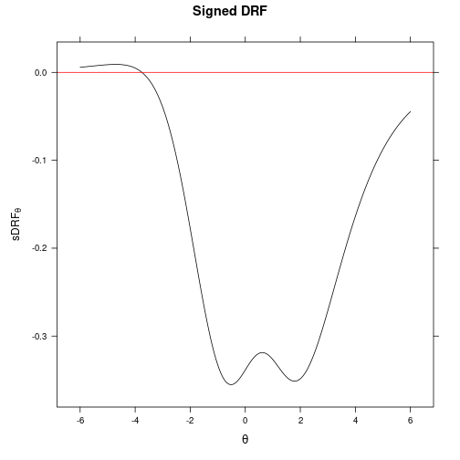

```r
DRF(mod, plot = TRUE)
```

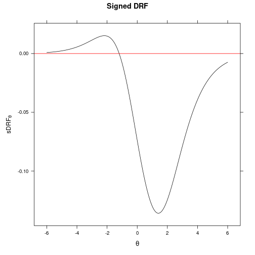

```r
DRF(mod, focal_items = 6:10, plot = TRUE) #DBF
```

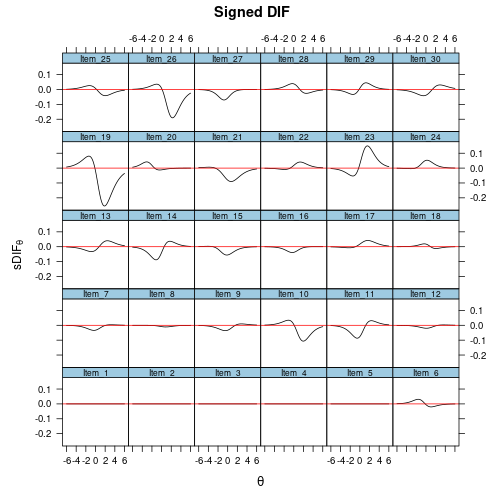

```r
DRF(mod, DIF=TRUE, plot = TRUE)
```

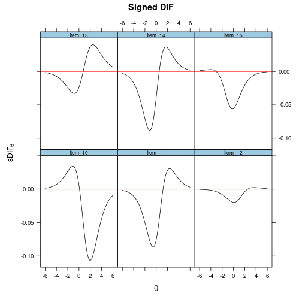

```r
DRF(mod, DIF=TRUE, focal_items = 10:15, plot = TRUE)
```

```r
if(interactive()) mirtCluster()
DRF(mod, draws = 500)
```

```
##               groups n_focal_items   stat CI_2.5 CI_97.5    X2 df     p
## sDRF Group_1,Group_2            30 -0.326 -1.007   0.416 0.841  1 0.359
## uDRF Group_1,Group_2            30  0.326  0.092   1.019 2.447  2 0.294
## dDRF Group_1,Group_2            30  0.328  0.112   1.140
```

```r
DRF(mod, draws = 500, best_fitting=TRUE)
```

```
##               groups n_focal_items   stat CI_2.5 CI_97.5    X2 df     p
## sDRF Group_1,Group_2            30 -0.326 -1.034   0.336 0.885  1 0.347
## uDRF Group_1,Group_2            30  0.326  0.095   1.042 2.342  2  0.31
## dDRF Group_1,Group_2            30  0.328  0.114   1.086
```

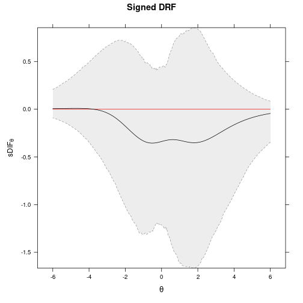

```r
DRF(mod, draws = 500, plot=TRUE)
```

```r
# pre-draw parameter set to save computations
#  (more useful when using non-parametric bootstrap)
param_set <- draw_parameters(mod, draws = 500)
DRF(mod, focal_items = 6, param_set=param_set) #DIF test
```

```
##               groups n_focal_items  stat CI_2.5 CI_97.5    X2 df     p
## sDRF Group_1,Group_2             1 0.000 -0.058   0.061     0  1 0.998
## uDRF Group_1,Group_2             1 0.016  0.006   0.079 0.809  2 0.667
## dDRF Group_1,Group_2             1 0.018  0.007   0.093
```

```r
DRF(mod, DIF=TRUE, param_set=param_set) #DIF test
```

```
## $sDIF
##             groups    item   sDIF CI_2.5 CI_97.5    X2 df     p
## 1  Group_1,Group_2  Item_1  0.000  0.000   0.000
## 2  Group_1,Group_2  Item_2  0.000  0.000   0.000
## 3  Group_1,Group_2  Item_3  0.000  0.000   0.000
## 4  Group_1,Group_2  Item_4  0.000  0.000   0.000
## 5  Group_1,Group_2  Item_5  0.000  0.000   0.000
## 6  Group_1,Group_2  Item_6  0.000 -0.058   0.061     0  1 0.998
## 7  Group_1,Group_2  Item_7 -0.026 -0.090   0.041 0.675  1 0.411
## 8  Group_1,Group_2  Item_8 -0.008 -0.074   0.055 0.057  1 0.812
## 9  Group_1,Group_2  Item_9 -0.026 -0.083   0.035  0.71  1 0.399
## 10 Group_1,Group_2 Item_10 -0.010 -0.070   0.048 0.112  1 0.738
## 11 Group_1,Group_2 Item_11 -0.056 -0.111   0.000 3.424  1 0.064
## 12 Group_1,Group_2 Item_12 -0.016 -0.074   0.043 0.286  1 0.593
## 13 Group_1,Group_2 Item_13 -0.015 -0.075   0.044 0.257  1 0.612
```

[output cut: 83 more lines]

```r
DRF(mod, focal_items = 6:10, param_set=param_set) #DBF test
```

```
##               groups n_focal_items   stat CI_2.5 CI_97.5    X2 df     p
## sDRF Group_1,Group_2             5 -0.069 -0.241   0.103 0.597  1  0.44
## uDRF Group_1,Group_2             5  0.071  0.019   0.245 2.118  2 0.347
## dDRF Group_1,Group_2             5  0.084  0.023   0.278
```

```r
DRF(mod, param_set=param_set) #DTF test
```

```
##               groups n_focal_items   stat CI_2.5 CI_97.5    X2 df     p
## sDRF Group_1,Group_2            30 -0.326 -0.925   0.355 0.947  1  0.33
## uDRF Group_1,Group_2            30  0.326  0.075   1.000  2.69  2 0.261
## dDRF Group_1,Group_2            30  0.328  0.090   1.047
```

```r
DRF(mod, focal_items = 6:10, draws=500) #DBF test
```

```
##               groups n_focal_items   stat CI_2.5 CI_97.5    X2 df     p
## sDRF Group_1,Group_2             5 -0.069 -0.238   0.102  0.63  1 0.427
## uDRF Group_1,Group_2             5  0.071  0.020   0.251 2.236  2 0.327
## dDRF Group_1,Group_2             5  0.084  0.024   0.283
```

```r
DRF(mod, focal_items = 10:15, draws=500) #DBF test
```

```
##               groups n_focal_items   stat CI_2.5 CI_97.5    X2 df     p
## sDRF Group_1,Group_2             6 -0.175 -0.384   0.035 2.698  1   0.1
## uDRF Group_1,Group_2             6  0.175  0.041   0.382 6.734  2 0.034
## dDRF Group_1,Group_2             6  0.185  0.051   0.409
```

```r
DIFs <- DRF(mod, draws = 500, DIF=TRUE)
print(DIFs)
```

```
## $sDIF
##             groups    item   sDIF CI_2.5 CI_97.5    X2 df     p
## 1  Group_1,Group_2  Item_1  0.000  0.000   0.000
## 2  Group_1,Group_2  Item_2  0.000  0.000   0.000
## 3  Group_1,Group_2  Item_3  0.000  0.000   0.000
## 4  Group_1,Group_2  Item_4  0.000  0.000   0.000
## 5  Group_1,Group_2  Item_5  0.000  0.000   0.000
## 6  Group_1,Group_2  Item_6  0.000 -0.065   0.064     0  1 0.998
## 7  Group_1,Group_2  Item_7 -0.026 -0.097   0.029 0.676  1 0.411
## 8  Group_1,Group_2  Item_8 -0.008 -0.067   0.053 0.061  1 0.805
## 9  Group_1,Group_2  Item_9 -0.026 -0.088   0.030 0.711  1 0.399
## 10 Group_1,Group_2 Item_10 -0.010 -0.066   0.055 0.112  1 0.738
## 11 Group_1,Group_2 Item_11 -0.056 -0.115  -0.001 3.612  1 0.057
## 12 Group_1,Group_2 Item_12 -0.016 -0.076   0.038 0.304  1 0.581
## 13 Group_1,Group_2 Item_13 -0.015 -0.076   0.039 0.239  1 0.625
```

[output cut: 83 more lines]

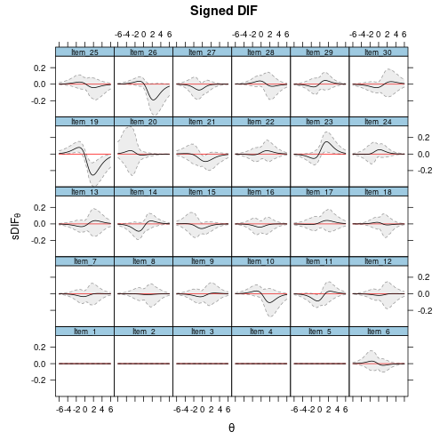

```r
DRF(mod, draws = 500, DIF=TRUE, plot=TRUE)
```

```r
DIFs <- DRF(mod, draws = 500, DIF=TRUE, focal_items = 6:10)
print(DIFs)
```

```
## $sDIF
##            groups    item   sDIF CI_2.5 CI_97.5    X2 df     p
## 1 Group_1,Group_2  Item_6  0.000 -0.065   0.061     0  1 0.998
## 2 Group_1,Group_2  Item_7 -0.026 -0.092   0.036 0.682  1 0.409
## 3 Group_1,Group_2  Item_8 -0.008 -0.072   0.049 0.057  1 0.811
## 4 Group_1,Group_2  Item_9 -0.026 -0.088   0.034 0.719  1 0.397
## 5 Group_1,Group_2 Item_10 -0.010 -0.074   0.051 0.102  1  0.75
##
## $uDIF
##            groups    item  uDIF CI_2.5 CI_97.5    X2 df     p
## 1 Group_1,Group_2  Item_6 0.016  0.006   0.082 0.689  2 0.708
## 2 Group_1,Group_2  Item_7 0.026  0.010   0.092 2.077  2 0.354
## 3 Group_1,Group_2  Item_8 0.008  0.007   0.078 0.203  2 0.903
## 4 Group_1,Group_2  Item_9 0.026  0.007   0.089 2.212  2 0.331
## 5 Group_1,Group_2 Item_10 0.036  0.010   0.092 3.641  2 0.162
##
## $dDIF
##            groups    item  dDIF CI_2.5 CI_97.5
## 1 Group_1,Group_2  Item_6 0.018  0.006   0.096
## 2 Group_1,Group_2  Item_7 0.028  0.011   0.100
## 3 Group_1,Group_2  Item_8 0.008  0.008   0.092
## 4 Group_1,Group_2  Item_9 0.028  0.008   0.099
## 5 Group_1,Group_2 Item_10 0.044  0.011   0.117
```

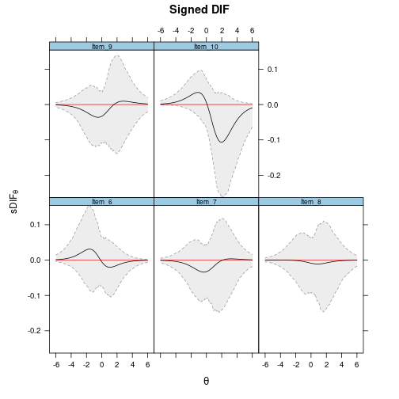

```r
DRF(mod, draws = 500, DIF=TRUE, focal_items = 6:10, plot = TRUE)
```

```r
DRF(mod, DIF=TRUE, focal_items = 6)
```

```
##            groups   item sDIF  uDIF  dDIF
## 1 Group_1,Group_2 Item_6    0 0.016 0.018
```

```r
DRF(mod, draws=500, DIF=TRUE, focal_items = 6)
```

```
## $sDIF
##            groups   item sDIF CI_2.5 CI_97.5 X2 df     p
## 1 Group_1,Group_2 Item_6    0 -0.062   0.066  0  1 0.999
##
## $uDIF
##            groups   item  uDIF CI_2.5 CI_97.5    X2 df   p
## 1 Group_1,Group_2 Item_6 0.016  0.008   0.086 0.713  2 0.7
##
## $dDIF
##            groups   item  dDIF CI_2.5 CI_97.5
## 1 Group_1,Group_2 Item_6 0.018  0.009   0.099
```

```r
# evaluate specific values for sDRF
Theta_nodes <- matrix(seq(-6,6,length.out = 100))

sDTF <- DRF(mod, Theta_nodes=Theta_nodes)
head(sDTF)
```

```
##         Theta  sDRF
## sDRF.1 -6.000 0.006
## sDRF.2 -5.879 0.006
## sDRF.3 -5.758 0.007
## sDRF.4 -5.636 0.007
## sDRF.5 -5.515 0.007
## sDRF.6 -5.394 0.008
```

```r
sDTF <- DRF(mod, Theta_nodes=Theta_nodes, draws=200)
head(sDTF)
```

```
##         Theta  sDRF CI_2.5 CI_97.5
## sDRF.1 -6.000 0.006 -0.084   0.197
## sDRF.2 -5.879 0.006 -0.092   0.211
## sDRF.3 -5.758 0.007 -0.102   0.224
## sDRF.4 -5.636 0.007 -0.112   0.239
## sDRF.5 -5.515 0.007 -0.123   0.254
## sDRF.6 -5.394 0.008 -0.135   0.269
```

```r
# sDIF (isolate single item)
sDIF <- DRF(mod, Theta_nodes=Theta_nodes, focal_items=6)
head(sDIF)
```

```
##         Theta  sDRF
## sDRF.1 -6.000 0.001
## sDRF.2 -5.879 0.001
## sDRF.3 -5.758 0.001
## sDRF.4 -5.636 0.002
## sDRF.5 -5.515 0.002
## sDRF.6 -5.394 0.002
```

```r
sDIF <- DRF(mod, Theta_nodes=Theta_nodes, focal_items = 6, draws=200)
head(sDIF)
```

```
##         Theta  sDRF CI_2.5 CI_97.5
## sDRF.1 -6.000 0.001 -0.004   0.020
## sDRF.2 -5.879 0.001 -0.005   0.022
## sDRF.3 -5.758 0.001 -0.005   0.024
## sDRF.4 -5.636 0.002 -0.006   0.026
## sDRF.5 -5.515 0.002 -0.007   0.028
## sDRF.6 -5.394 0.002 -0.007   0.030
```

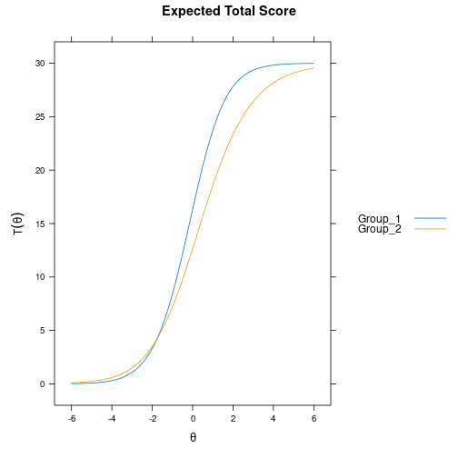

```r
## -------------
## random slopes and intercepts for 15 items, and latent mean difference
##    (no systematic DTF should exist, but DIF will be present)
set.seed(1234)
dat1 <- simdata(a, d, N, itemtype = 'dich', mu=.50, sigma=matrix(1.5))
dat2 <- simdata(a + c(numeric(15), rnorm(n-15, 0, .25)),
                d + c(numeric(15), rnorm(n-15, 0, .5)), N, itemtype = 'dich')
dat <- rbind(dat1, dat2)
mod1 <- multipleGroup(dat, 1, group=group)
plot(mod1)
```

```r
DRF(mod1) #does not account for group differences! Need anchors
```

```
## No hyper-parameters were estimated in the DIF model. For effective
##                 	DRF testing freeing the focal group hyper-parameters is recommended.
```

```
##            groups n_focal_items  sDRF  uDRF  dDRF
## 1 Group_1,Group_2            30 -3.25 3.268 3.642
```

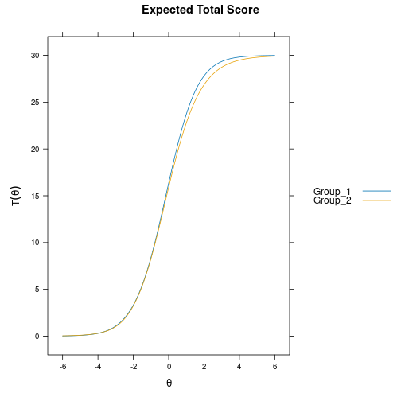

```r
mod2 <- multipleGroup(dat, model, group=group, SE=TRUE,
                      invariance=c('free_means', 'free_var'))
plot(mod2)
```

```r
# significant DIF in multiple items....
# DIF(mod2, which.par=c('a1', 'd'), items2test=16:30)
DRF(mod2)
```

```
##            groups n_focal_items   sDRF  uDRF dDRF
## 1 Group_1,Group_2            30 -0.421 0.421 0.51
```

```r
DRF(mod2, draws=500) #non-sig DTF due to item cancellation
```

```
##               groups n_focal_items   stat CI_2.5 CI_97.5    X2 df     p
## sDRF Group_1,Group_2            30 -0.421 -1.133   0.238 1.476  1 0.224
## uDRF Group_1,Group_2            30  0.421  0.169   1.186 4.437  2 0.109
## dDRF Group_1,Group_2            30  0.510  0.232   1.334
```

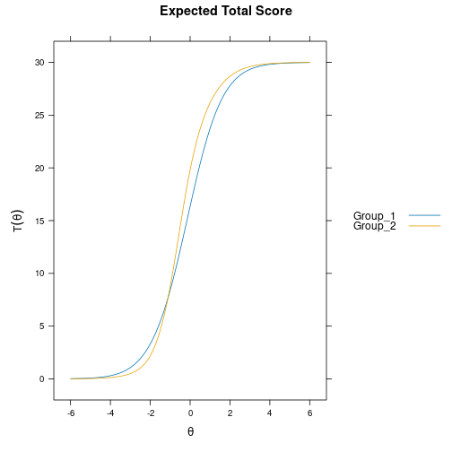

```r
## -------------
## systematic differing slopes and intercepts (clear DTF)
set.seed(1234)
dat1 <- simdata(a, d, N, itemtype = 'dich', mu=.50, sigma=matrix(1.5))
dat2 <- simdata(a + c(numeric(15), rnorm(n-15, 1, .25)),
                d + c(numeric(15), rnorm(n-15, 1, .5)),
                N, itemtype = 'dich')
dat <- rbind(dat1, dat2)
mod3 <- multipleGroup(dat, model, group=group, SE=TRUE,
                      invariance=c('free_means', 'free_var'))
plot(mod3) #visable DTF happening
```

```r
# DIF(mod3, c('a1', 'd'), items2test=16:30)
DRF(mod3) #unsigned bias. Signed bias (group 2 scores higher on average)
```

```
##            groups n_focal_items  sDRF  uDRF  dDRF
## 1 Group_1,Group_2            30 1.983 2.192 2.471
```

```r
DRF(mod3, draws=500)
```

```
##               groups n_focal_items  stat CI_2.5 CI_97.5     X2 df p
## sDRF Group_1,Group_2            30 1.983  1.263   2.634 30.314  1 0
## uDRF Group_1,Group_2            30 2.192  1.520   2.785 50.951  2 0
## dDRF Group_1,Group_2            30 2.471  1.708   3.140
```

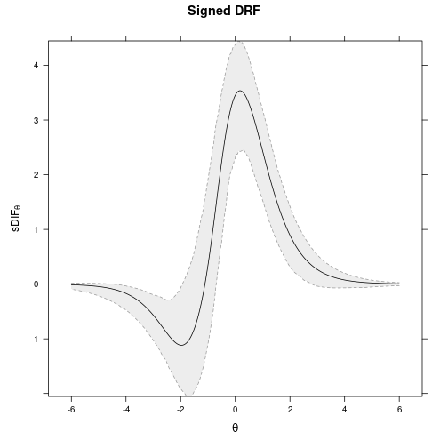

```r
DRF(mod3, draws=500, plot=TRUE) #multiple DRF areas along Theta
```

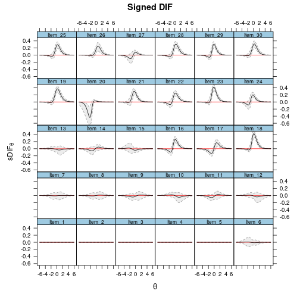

```r
# plot the DIF
DRF(mod3, draws=500, DIF=TRUE, plot=TRUE)
```

```r
# evaluate specific values for sDRF
Theta_nodes <- matrix(seq(-6,6,length.out = 100))
sDTF <- DRF(mod3, Theta_nodes=Theta_nodes, draws=200)
head(sDTF)
```

```
##         Theta   sDRF CI_2.5 CI_97.5
## sDRF.1 -6.000 -0.012 -0.077   0.014
## sDRF.2 -5.879 -0.014 -0.087   0.015
## sDRF.3 -5.758 -0.016 -0.098   0.016
## sDRF.4 -5.636 -0.019 -0.110   0.016
## sDRF.5 -5.515 -0.022 -0.124   0.017
## sDRF.6 -5.394 -0.026 -0.139   0.017
```

```r
# DIF
sDIF <- DRF(mod3, Theta_nodes=Theta_nodes, focal_items = 30, draws=200)
car::some(sDIF)
```

```
##          Theta   sDRF CI_2.5 CI_97.5
## sDRF.5  -5.515  0.000 -0.003   0.000
## sDRF.25 -3.091 -0.008 -0.029   0.001
## sDRF.40 -1.273  0.015 -0.058   0.105
## sDRF.45 -0.667  0.135  0.032   0.241
## sDRF.64  1.636  0.129  0.072   0.197
## sDRF.67  2.000  0.086  0.042   0.149
## sDRF.81  3.697  0.010  0.003   0.030
## sDRF.87  4.424  0.004  0.001   0.014
## sDRF.91  4.909  0.002  0.000   0.009
## sDRF.92  5.030  0.002  0.000   0.008
```

```r
## ----------------------------------------------------------------
# polytomous example
# simulate data where group 2 has a different slopes/intercepts
set.seed(4321)
a1 <- a2 <- matrix(rlnorm(20,.2,.3))
a2[c(16:17, 19:20),] <- a1[c(16:17, 19:20),] + c(-.5, -.25, .25, .5)

# for the graded model, ensure that there is enough space between the intercepts,
# otherwise closer categories will not be selected often
diffs <- t(apply(matrix(runif(20*4, .3, 1), 20), 1, cumsum))
diffs <- -(diffs - rowMeans(diffs))
d1 <- d2 <- diffs + rnorm(20)
rownames(d1) <- rownames(d2) <- paste0('Item.', 1:20)
d2[16:20,] <- d1[16:20,] + matrix(c(-.5, -.5, -.5, -.5,
                                    1, 0, 0, -1,
                                    .5, .5, -.5, -.5,
                                    1, .5, 0, -1,
                                    .5, .5, .5, .5), byrow=TRUE, nrow=5)

tail(data.frame(a.group1 = a1, a.group2 = a2), 6)
```

```
##     a.group1  a.group2
## 15 0.8465935 0.8465935
## 16 1.9581395 1.4581395
## 17 1.2486255 0.9986255
## 18 0.8585293 0.8585293
## 19 0.7584499 1.0084499
## 20 0.9760766 1.4760766
```

```r
list(d.group1 = d1[15:20,], d.group2 = d2[15:20,])
```

```
## $d.group1
##              [,1]       [,2]        [,3]          [,4]
## Item.15 2.0841033  1.2423287  0.38217647 -0.0009005437
## Item.16 0.2454193 -0.2924192 -0.63521843 -1.5254133343
## Item.17 1.3003614  0.5847340 -0.09046573 -0.9841542611
## Item.18 1.5079114  0.6489106 -0.03799347 -0.3892116221
## Item.19 1.3766077  0.4483499 -0.20715833 -0.8701328534
## Item.20 0.1461006 -0.8364834 -1.32963653 -1.6894534436
##
## $d.group2
##               [,1]       [,2]        [,3]          [,4]
## Item.15  2.0841033  1.2423287  0.38217647 -0.0009005437
## Item.16 -0.2545807 -0.7924192 -1.13521843 -2.0254133343
## Item.17  2.3003614  0.5847340 -0.09046573 -1.9841542611
## Item.18  2.0079114  1.1489106 -0.53799347 -0.8892116221
## Item.19  2.3766077  0.9483499 -0.20715833 -1.8701328534
## Item.20  0.6461006 -0.3364834 -0.82963653 -1.1894534436
```

```r
itemtype <- rep('graded', nrow(a1))
N <- 600
dataset1 <- simdata(a1, d1, N, itemtype)
dataset2 <- simdata(a2, d2, N, itemtype, mu = -.25, sigma = matrix(1.25))
dat <- rbind(dataset1, dataset2)
group <- c(rep('D1', N), rep('D2', N))

# item 1-10 as anchors
mod <- multipleGroup(dat, group=group, SE=TRUE,
                     invariance=c(colnames(dat)[1:10], 'free_means', 'free_var'))
coef(mod, simplify=TRUE)
```

```
## $D1
## $items
##            a1     d1     d2     d3     d4
## Item_1  1.194  0.911  0.177 -0.462 -1.105
## Item_2  1.320  0.787  0.362 -0.152 -0.951
## Item_3  1.561  0.794  0.013 -0.973 -1.774
## Item_4  1.491  1.977  1.304  0.284 -0.236
## Item_5  1.249  1.435  0.351 -0.329 -1.273
## Item_6  2.071  0.517  0.072 -0.564 -1.551
## Item_7  1.333  0.157 -0.374 -0.848 -1.911
## Item_8  1.304  1.117  0.512 -0.467 -0.868
## Item_9  1.830  1.501  0.639 -0.176 -0.906
## Item_10 1.073  1.485  0.567 -0.190 -0.812
## Item_11 1.327  2.039  1.529  0.756 -0.283
## Item_12 1.481 -0.268 -1.021 -1.534 -2.229
## Item_13 0.812  0.641  0.086 -0.832 -1.977
## Item_14 1.713  1.850  1.191  0.511 -0.262
## Item_15 0.913  2.168  1.401  0.468  0.058
## Item_16 2.245  0.286 -0.345 -0.728 -1.687
## Item_17 1.233  1.357  0.673  0.057 -0.916
## Item_18 0.983  1.515  0.625 -0.171 -0.564
## Item_19 0.946  1.415  0.521 -0.227 -0.966
## Item_20 0.847  0.181 -0.828 -1.245 -1.624
##
## $means
## F1
##  0
##
## $cov
##    F1
## F1  1
##
##
## $D2
## $items
##            a1     d1     d2     d3     d4
## Item_1  1.194  0.911  0.177 -0.462 -1.105
## Item_2  1.320  0.787  0.362 -0.152 -0.951
## Item_3  1.561  0.794  0.013 -0.973 -1.774
## Item_4  1.491  1.977  1.304  0.284 -0.236
```

[output cut: 9 more lines]

```
## Item_14 2.147  2.155  1.311  0.566 -0.248
## Item_15 0.889  2.101  1.164  0.343 -0.010
## Item_16 1.622 -0.395 -0.979 -1.278 -2.255
## Item_17 1.060  2.345  0.587 -0.113 -2.040
## Item_18 0.923  1.860  1.099 -0.508 -0.793
## Item_19 1.051  2.528  0.960 -0.227 -1.976
## Item_20 1.456  0.690 -0.277 -0.806 -1.164
##
## $means
##     F1
## -0.303
##
## $cov
##       F1
## F1 1.147
```

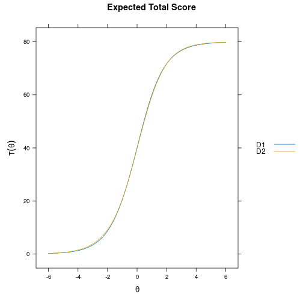

```r
plot(mod)
```

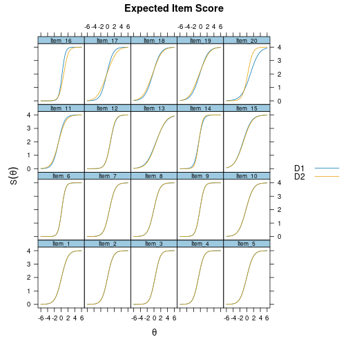

```r
plot(mod, type='itemscore')
```

```r
# DIF tests vis Wald method
DIF(mod, items2test=11:20,
   which.par=c('a1', paste0('d', 1:4)),
   Wald=TRUE, p.adjust='holm')
```

```
##         groups       W df     p adj_p
## Item_11  D1,D2   5.854  5 0.321     1
## Item_12  D1,D2   4.808  5  0.44     1
## Item_13  D1,D2   6.854  5 0.232     1
## Item_14  D1,D2   4.854  5 0.434     1
## Item_15  D1,D2   3.861  5  0.57     1
## Item_16  D1,D2  35.919  5     0     0
## Item_17  D1,D2 121.671  5     0     0
## Item_18  D1,D2  45.135  5     0     0
## Item_19  D1,D2  96.182  5     0     0
## Item_20  D1,D2  32.769  5     0     0
```

```r
DRF(mod)
```

```
##   groups n_focal_items   sDRF  uDRF  dDRF
## 1  D1,D2            20 -0.195 0.329 0.382
```

```r
DRF(mod, DIF=TRUE, focal_items=11:20)
```

```
##    groups    item   sDIF  uDIF  dDIF
## 1   D1,D2 Item_11 -0.080 0.119 0.131
## 2   D1,D2 Item_12  0.011 0.024 0.031
## 3   D1,D2 Item_13 -0.068 0.069 0.072
## 4   D1,D2 Item_14 -0.010 0.121 0.134
## 5   D1,D2 Item_15 -0.083 0.083 0.085
## 6   D1,D2 Item_16 -0.393 0.402 0.522
## 7   D1,D2 Item_17 -0.053 0.219 0.248
## 8   D1,D2 Item_18  0.038 0.093 0.110
## 9   D1,D2 Item_19  0.073 0.104 0.122
## 10  D1,D2 Item_20  0.370 0.425 0.542
```

```r
DRF(mod, DIF.cats=TRUE, focal_items=11:20)
```

```
##    groups    item cat   sDIF  uDIF  dDIF
## 1   D1,D2 Item_11   1  0.009 0.021 0.024
## 2   D1,D2 Item_11   2  0.012 0.012 0.012
## 3   D1,D2 Item_11   3 -0.010 0.015 0.018
## 4   D1,D2 Item_11   4  0.032 0.032 0.034
## 5   D1,D2 Item_11   5 -0.041 0.045 0.056
## 6   D1,D2 Item_12   1 -0.004 0.008 0.010
## 7   D1,D2 Item_12   2 -0.015 0.015 0.017
## 8   D1,D2 Item_12   3  0.031 0.031 0.036
## 9   D1,D2 Item_12   4 -0.013 0.013 0.015
## 10  D1,D2 Item_12   5  0.001 0.005 0.008
## 11  D1,D2 Item_13   1  0.012 0.012 0.015
## 12  D1,D2 Item_13   2  0.017 0.017 0.018
## 13  D1,D2 Item_13   3  0.010 0.013 0.016
## 14  D1,D2 Item_13   4 -0.050 0.050 0.053
```

[output cut: 36 more lines]

```r
## ----------------------------------------------------------------
### multidimensional DTF

set.seed(1234)
n <- 50
N <- 1000

# only first 5 items as anchors within each dimension
model <- 'F1 = 1-25
          F2 = 26-50
          COV = F1*F2
          CONSTRAINB = (1-5, a1), (1-5, 26-30, d), (26-30, a2)'

a <- matrix(c(rep(1, 25), numeric(50), rep(1, 25)), n)
d <- matrix(rnorm(n), n)
group <- c(rep('Group_1', N), rep('Group_2', N))
Cov <- matrix(c(1, .5, .5, 1.5), 2)
Mean <- c(0, 0.5)

# groups completely equal
dat1 <- simdata(a, d, N, itemtype = 'dich', sigma = cov2cor(Cov))
dat2 <- simdata(a, d, N, itemtype = 'dich', sigma = Cov, mu = Mean)
dat <- rbind(dat1, dat2)
mod <- multipleGroup(dat, model, group=group, SE=TRUE,
                     invariance=c('free_means', 'free_var'))
coef(mod, simplify=TRUE)
```

```
## $Group_1
## $items
##            a1    a2      d g u
## Item_1  1.006 0.000 -1.208 0 1
## Item_2  1.080 0.000  0.301 0 1
## Item_3  0.833 0.000  1.126 0 1
## Item_4  0.977 0.000 -2.342 0 1
## Item_5  1.005 0.000  0.410 0 1
## Item_6  0.864 0.000  0.428 0 1
## Item_7  1.014 0.000 -0.495 0 1
## Item_8  1.133 0.000 -0.472 0 1
## Item_9  0.945 0.000 -0.585 0 1
## Item_10 1.001 0.000 -0.787 0 1
## Item_11 1.009 0.000 -0.390 0 1
## Item_12 0.920 0.000 -1.061 0 1
## Item_13 1.189 0.000 -0.711 0 1
## Item_14 1.125 0.000  0.066 0 1
## Item_15 1.122 0.000  0.896 0 1
## Item_16 1.094 0.000 -0.203 0 1
## Item_17 1.041 0.000 -0.479 0 1
## Item_18 1.011 0.000 -0.849 0 1
## Item_19 0.962 0.000 -0.768 0 1
## Item_20 0.937 0.000  2.372 0 1
## Item_21 0.935 0.000  0.082 0 1
## Item_22 0.886 0.000 -0.482 0 1
## Item_23 0.921 0.000 -0.443 0 1
## Item_24 0.937 0.000  0.521 0 1
## Item_25 0.959 0.000 -0.674 0 1
## Item_26 0.000 0.999 -1.498 0 1
## Item_27 0.000 0.978  0.590 0 1
## Item_28 0.000 0.997 -1.035 0 1
## Item_29 0.000 0.917 -0.055 0 1
## Item_30 0.000 0.982 -0.970 0 1
## Item_31 0.000 0.891  0.931 0 1
## Item_32 0.000 0.863 -0.453 0 1
## Item_33 0.000 1.140 -0.759 0 1
## Item_34 0.000 0.943 -0.469 0 1
## Item_35 0.000 1.289 -1.852 0 1
## Item_36 0.000 0.791 -1.064 0 1
## Item_37 0.000 0.980 -2.323 0 1
```

[output cut: 71 more lines]

```
## Item_45 0.000 0.844 -0.728 0 1
## Item_46 0.000 1.068 -1.046 0 1
## Item_47 0.000 0.952 -1.123 0 1
## Item_48 0.000 1.018 -1.317 0 1
## Item_49 0.000 0.881 -0.381 0 1
## Item_50 0.000 1.092 -0.605 0 1
##
## $means
##    F1    F2
## 0.072 0.505
##
## $cov
##       F1    F2
## F1 1.067 0.518
## F2 0.518 1.415
```

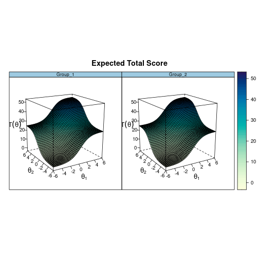

```r
plot(mod, degrees = c(45,45))
```

```r
DRF(mod)
```

```
##            groups n_focal_items   sDRF  uDRF  dDRF
## 1 Group_1,Group_2            50 -0.347 0.347 0.353
```

```r
# some intercepts slightly higher in Group 2
d2 <- d
d2[c(10:15, 31:35)] <- d2[c(10:15, 31:35)] + 1
dat1 <- simdata(a, d, N, itemtype = 'dich', sigma = cov2cor(Cov))
dat2 <- simdata(a, d2, N, itemtype = 'dich', sigma = Cov, mu = Mean)
dat <- rbind(dat1, dat2)
mod <- multipleGroup(dat, model, group=group, SE=TRUE,
                     invariance=c('free_means', 'free_var'))
coef(mod, simplify=TRUE)
```

```
## $Group_1
## $items
##            a1    a2      d g u
## Item_1  0.942 0.000 -1.195 0 1
## Item_2  0.973 0.000  0.294 0 1
## Item_3  0.833 0.000  1.131 0 1
## Item_4  1.049 0.000 -2.575 0 1
## Item_5  1.078 0.000  0.517 0 1
## Item_6  0.919 0.000  0.456 0 1
## Item_7  0.929 0.000 -0.473 0 1
## Item_8  0.918 0.000 -0.554 0 1
## Item_9  0.907 0.000 -0.582 0 1
## Item_10 1.096 0.000 -0.821 0 1
## Item_11 1.000 0.000 -0.483 0 1
## Item_12 0.986 0.000 -1.016 0 1
## Item_13 1.013 0.000 -0.870 0 1
## Item_14 0.861 0.000  0.104 0 1
## Item_15 1.097 0.000  0.908 0 1
## Item_16 0.871 0.000 -0.119 0 1
## Item_17 0.949 0.000 -0.417 0 1
## Item_18 1.019 0.000 -0.987 0 1
## Item_19 1.031 0.000 -0.962 0 1
## Item_20 0.904 0.000  2.378 0 1
## Item_21 1.177 0.000  0.061 0 1
## Item_22 1.044 0.000 -0.551 0 1
## Item_23 0.948 0.000 -0.510 0 1
## Item_24 0.915 0.000  0.387 0 1
## Item_25 0.901 0.000 -0.778 0 1
## Item_26 0.000 0.979 -1.450 0 1
## Item_27 0.000 0.999  0.603 0 1
## Item_28 0.000 1.105 -1.108 0 1
## Item_29 0.000 1.034  0.043 0 1
## Item_30 0.000 0.974 -0.925 0 1
## Item_31 0.000 0.982  1.258 0 1
## Item_32 0.000 1.012 -0.407 0 1
## Item_33 0.000 0.957 -0.619 0 1
## Item_34 0.000 1.076 -0.548 0 1
## Item_35 0.000 0.761 -1.608 0 1
## Item_36 0.000 0.962 -1.091 0 1
## Item_37 0.000 0.891 -2.076 0 1
```

[output cut: 71 more lines]

```
## Item_45 0.000 1.062 -1.103 0 1
## Item_46 0.000 1.064 -0.951 0 1
## Item_47 0.000 1.025 -1.122 0 1
## Item_48 0.000 0.975 -1.194 0 1
## Item_49 0.000 1.083 -0.461 0 1
## Item_50 0.000 0.935 -0.512 0 1
##
## $means
##    F1    F2
## 0.003 0.578
##
## $cov
##       F1    F2
## F1 1.165 0.459
## F2 0.459 1.340
```

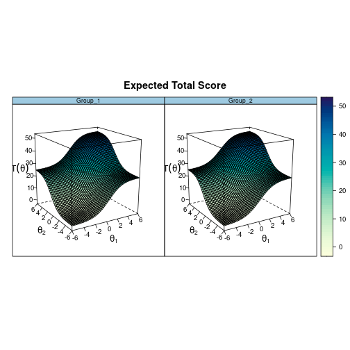

```r
plot(mod, degrees = c(45,45))
```

```r
DRF(mod)
```

```
##            groups n_focal_items  sDRF  uDRF  dDRF
## 1 Group_1,Group_2            50 1.803 1.803 1.831
```

```r
DRF(mod, draws = 500)
```

```
##               groups n_focal_items  stat CI_2.5 CI_97.5     X2 df p
## sDRF Group_1,Group_2            50 1.803  1.279   2.350 40.994  1 0
## uDRF Group_1,Group_2            50 1.803  1.280   2.350 43.448  2 0
## dDRF Group_1,Group_2            50 1.831  1.338   2.386
```

```r
## End(No test)
```

[Package *mirt* version 1.43 Index]